# Talent Retention Study

Lei Jiang

December 5, 2018

## Introduction

#### DDSAnalytics is an analytics company that specializes in talent management solutions for Fortune 1000 companies. Talent management is defined as the iterative process of developing and retaining employees. It may include workforce planning, employee training programs, identifying high-potential employees and reducing/preventing voluntary employee turnover (attrition). To gain a competitive edge over its competition, DDSAnalytics is planning to leverage data science for talent management. The executive leadership has identified predicting employee turnover as its first application of data science for talent management. Before the business green lights the project, they have tasked your data science team to conduct an analysis of existing employee data.

## Objectives

#### Identify the top features that contribute to employee retention.

#### Identify job role specific trends.

#### Build classification models to predict employee turnover using existing employee data.

## Exploratory data analysis

```r
DF <- read.csv("C:/Users/N1110/Desktop/CaseStudy2-data.csv",header=TRUE)

dim(DF)
```

```
## [1] 1170   37
```

```r
str(DF)
```

```
## 'data.frame':    1170 obs. of  37 variables:
##  $ ID                      : int  1 2 3 4 5 6 7 8 9 10 ...
##  $ Age                     : int  31 51 27 24 45 32 42 47 20 31 ...
##  $ Attrition               : Factor w/ 2 levels "No","Yes": 2 1 1 1 1 2 1 1 2 1 ...
##  $ BusinessTravel          : Factor w/ 3 levels "Non-Travel","Travel_Frequently",..: 3 3 1 1 3 3 2 2 2 2 ...
##  $ DailyRate               : int  359 1405 443 1269 193 1045 1271 1309 769 798 ...
##  $ Department              : Factor w/ 3 levels "Human Resources",..: 1 2 2 2 2 3 2 3 3 2 ...
##  $ DistanceFromHome        : int  18 11 3 4 6 4 2 4 9 7 ...
##  $ Education               : int  5 2 3 1 4 4 1 1 3 2 ...
##  $ EducationField          : Factor w/ 6 levels "Human Resources",..: 1 6 4 2 5 4 4 4 3 2 ...
##  $ EmployeeCount           : int  1 1 1 1 1 1 1 1 1 1 ...
##  $ EmployeeNumber          : int  1842 1367 850 888 101 291 875 467 1077 442 ...
##  $ EnvironmentSatisfaction : int  4 4 4 1 4 4 2 2 4 3 ...
##  $ Gender                  : Factor w/ 2 levels "Female","Male": 2 1 2 2 2 2 2 2 1 1 ...
##  $ HourlyRate              : int  89 82 50 46 52 32 35 99 54 48 ...
```

[output cut: 23 more lines]

```r
#9 factors, 27 integers, 1 random number

#Data Distribution

# Check Missing Data, there is no missing value
naCount<- colSums(is.na(DF))
naCount
```

```
##                       ID                      Age                Attrition
##                        0                        0                        0
##           BusinessTravel                DailyRate               Department
##                        0                        0                        0
##         DistanceFromHome                Education           EducationField
##                        0                        0                        0
##            EmployeeCount           EmployeeNumber  EnvironmentSatisfaction
##                        0                        0                        0
##                   Gender               HourlyRate           JobInvolvement
##                        0                        0                        0
##                 JobLevel                  JobRole          JobSatisfaction
##                        0                        0                        0
##            MaritalStatus            MonthlyIncome              MonthlyRate
##                        0                        0                        0
##       NumCompaniesWorked                   Over18                 OverTime
##                        0                        0                        0
##        PercentSalaryHike        PerformanceRating RelationshipSatisfaction
##                        0                        0                        0
##            StandardHours         StockOptionLevel        TotalWorkingYears
##                        0                        0                        0
##    TrainingTimesLastYear          WorkLifeBalance           YearsAtCompany
##                        0                        0                        0
##       YearsInCurrentRole  YearsSinceLastPromotion     YearsWithCurrManager
##                        0                        0                        0
##                     Rand
##                        0
```

```r
#data imbalance, more than 80% No, less than 20% yes. attrition  yes means the employee left, no means retained, so most employee in this study retained.
# attrition level: yes 2 , no 1

table(DF$Attrition)
```

```
##
##  No Yes
## 982 188
```

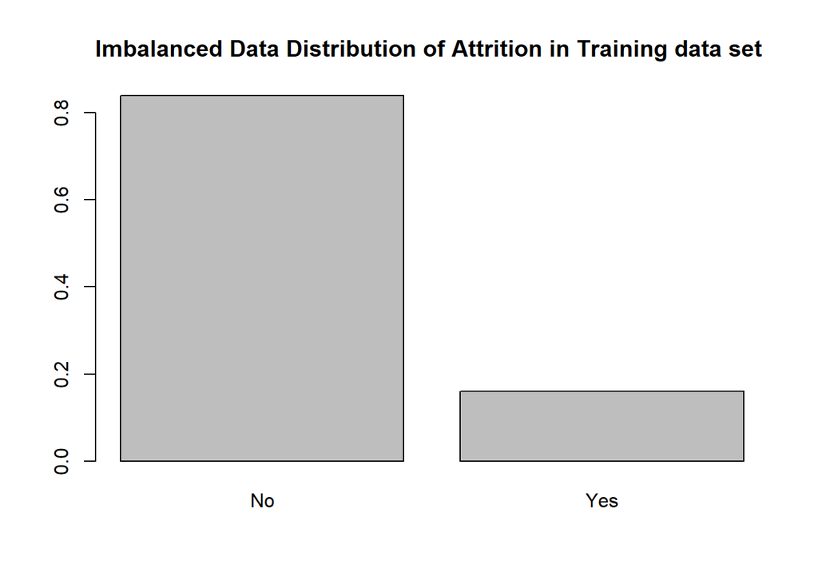

```r
barplot(prop.table(table(DF$Attrition)), main="Imbalanced Data Distribution of Attrition in Training data set ")
```

### Objective 1. Identify (at least) the top three factors that contribute to turnover.

#### Analysis of feature importance using correlation matrix was perfomed next.

#### By observing the data, we identified a number of varaibles are not related to our outcome, or constant for all observations and therefore has no value to be included in the correlation matrix analysis.

#### Identifying the most important features for outcome AttritionInt from correlation matrix created by R, the process is described here:

To measure the correlation, we need to use relative importance rather than absolute ones since we can only pick features from the data we have.

Features with absolute value of Pearson correlation coefficient equal or greater than 0.06 are as following: (positive correlation means bad effect to Attrition and vers versa)

Age (-0.13), DailyRate (-0.07), DistanceFromHome (0.07), EnvironmentSatisfaction (-0.13) , JobInvolvement (-0.15) , JobLevel(-0.15) ,JobSatisfaction (-0.09), MonthlyIncome (-0.14),StockOptionLevel (-0.14), TotalWorkingYears(-0.15), WorkLifeBalance (-0.09), YearsAtCompany(-0.12), YearsInCurrentRole(-0.15), YearsWithCurrManager(-0.14), TrainingTimesLastYear (-0.06), NumCompaniesWorked(0.06)

So after removing correlated features, we have these features highly correlated in the order of importance from high to low:

JobInvolvement (-0.15) , JobLevel(-0.15) , YearsInCurrentRole(-0.15), MonthlyIncome (-0.14),StockOptionLevel (-0.14), Age (-0.13), EnvironmentSatisfaction (-0.13) , WorkLifeBalance (-0.09), JobSatisfaction (-0.09), DistanceFromHome (0.07),TrainingTimesLastYear (-0.06), NumCompaniesWorked(0.06)

Also notice that these are only quantitative features; there are features recorded as factors, like EducationField, Department (leves 1-3), BusinessTravel (leves 1-3), gender(levels 1,2), jobrole (9 levels), OverTime (levels 1,2), maritalStatus(levels 1,2,3) that we could not quantify. So in this step we did not consider them in. We may need to use OneHotEncoder on catagorical varabiles. From this finding during EDA, I think change all factor features to int when read.csv the data at the begining may be better. This is how I made the decision. However, from here, we just change factor varaibles to int or numeric and check the correlation with our outcome. Remember we need to do the same thing to Validation DF in order to test our model.

(Trial: For the same reason of transformed “Attrition” to INT, “OverTime” and “Gender” could be transformed into INT and, test for correlation with “Attrition”.

For “BusinessTravel”, “Department”, “EducationField”, “JobRole”, “MaritalStatus” I am not sure about how use One Hot Encoding to transform them. But I tried after converting into INT and test for correlation with “Attrition”, we found features highly correlated with outcome are MaritalStatus (0.18), OverTime (0.24), and Department (0.08). So OverTime has great positive impact on Attrition and therefore great negative impact on retention (we can even create another outcome called “Retention” which is opposite of “Attrition”, such as Attrition levels: yes 2 , no 1; Retention levels: yes 1 , no 2). We can argue that JobRole (0.06) might also be important, it is a judgemental call.

Our study found, Gender (0.05), and businessTravel (-0.02) actually do not have much impact on Attrition.)

In conclusion, in order to retain the talents for the company, the following features, JobInvolvement (-0.15) , Age (-0.13), JobLevel(-0.15) , YearsInCurrentRole(-0.15), MaritalStatus (0.18) of the empoloyee are important but, are these are features the company can not control (unless they only hire more experienced people or not married people). For feature Department (0.08), we need every Departments in the company to operate, so we can not choose to hire people for only a certain Department. Thus, we can not work to improve this one either. We can suggest the company to improve on features that the company can control on their side, such as MonthlyIncome (-0.14),StockOptionLevel (-0.14), EnvironmentSatisfaction (-0.13) , and WorkLifeBalance (-0.09). So my conclusion is these four factors stated above are the most important factors I found that contribute to turnover from the dataset we were given.

Combine the two studies above together, we have these 16 features highly correlated in the order of importance from high to low might be useful to build our model for later:

OverTime (0.24), MaritalStatus (0.18),JobInvolvement (-0.15) , JobLevel(-0.15) , YearsInCurrentRole(-0.15), MonthlyIncome (-0.14),StockOptionLevel (-0.14), Age (-0.13), EnvironmentSatisfaction (-0.13) , WorkLifeBalance (-0.09), JobSatisfaction (-0.09), Department (0.08), DistanceFromHome (0.07), JobRole (0.06), TrainingTimesLastYear (-0.06), NumCompaniesWorked(0.06).

(OverTime (0.24) is kind of correlated to WorkLifeBalance (-0.09) by definition. However, after check the correlation matrix, we found it is not highly correlated.)

I will choose these for top features, since they are listed top scores in both correlation matrix and RF model. Also, these featurescan be easily transferred to actionable items for the company. OverTime (0.24), JobInvolvement (-0.15), JobLevel(-0.15), MonthlyIncome (-0.14), StockOptionLevel (-0.14)

```r
# For the correlation matrix, Remove columns that are not necessary EmployeeCount(all values are 1, not helpful in our study),  StandardHours (all values are 80), Over18(all value Y),
# EmployeeNumber? what does Rand mean?

DF2 <- subset(DF, select = -c(ID, EmployeeCount,StandardHours, Over18))

DF2$OverTimeINT  <- as.integer(DF$OverTime)
DF2$GenderINT  <- as.integer(DF$Gender)

#OneHotEncoding for Attrition. used "Int" in the name of transformed Attrition to label it as outcome. Later, some transformed features  will be labled as "INT".
DF2$AttritionInt <- as.integer(DF$Attrition)
#after change Attrtition to Int, 1,2, 1 means yes, 2 means no.
#so greater positive corr with AttritionInt means Attrition no->retained.??
# but result opposite in lower matrix part. therefore, so greater negative corr with AttritionInt means Attrition no->retained.


#choose only numeric columns
nums <- unlist(lapply(DF2, is.numeric))
DFnum<- DF2[ , nums]

# create correlation matrix, heatmap of correlation matrix is for visual reference when selecting the important features; we can not only rely on heatmap.
cormat <- round(cor(DFnum),2)
#head(cormat)


library(reshape2)
melted_cormat <- melt(cormat)
head(melted_cormat)
```

```
##                      Var1 Var2 value
## 1                     Age  Age  1.00
## 2               DailyRate  Age  0.02
## 3        DistanceFromHome  Age -0.01
## 4               Education  Age  0.20
## 5          EmployeeNumber  Age  0.00
## 6 EnvironmentSatisfaction  Age  0.00
```

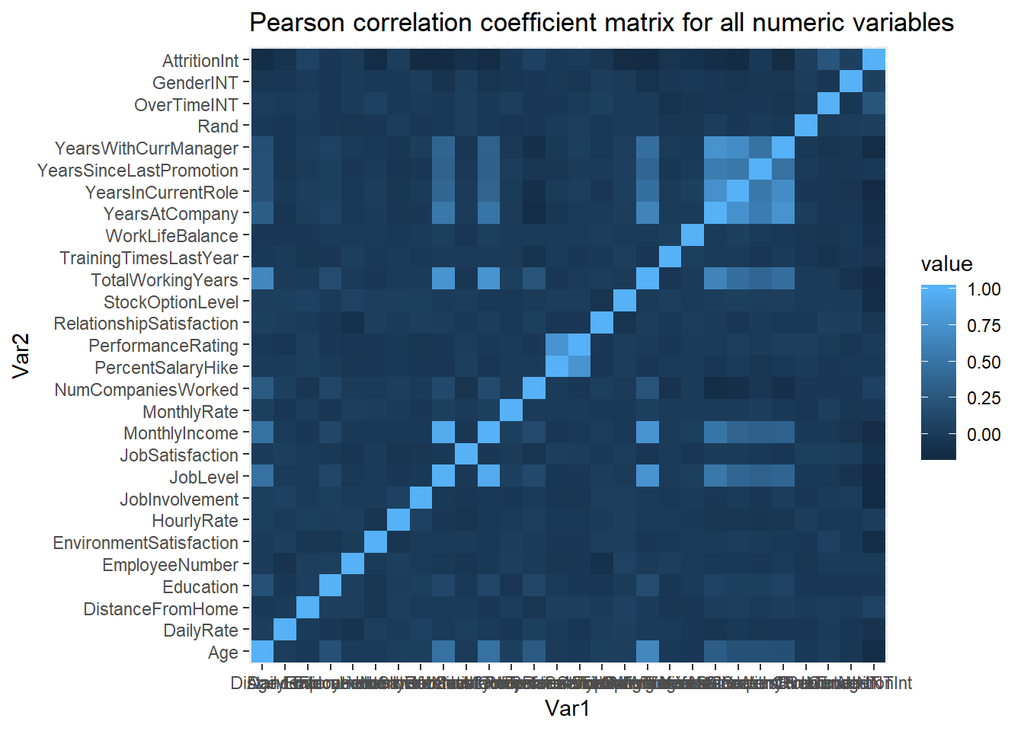

```r
library(ggplot2)
ggplot(data = melted_cormat, aes(x=Var1, y=Var2, fill=value)) +
  geom_tile()+ggtitle("Pearson correlation coefficient matrix for all numeric variables")
```

```r
# Get upper triangle of the correlation matrix
  get_upper_tri <- function(cormat){
    cormat[lower.tri(cormat)]<- NA
    return(cormat)
  }


upper_tri <- get_upper_tri(cormat)
upper_tri  # can choose to print out the whole table or not
```

```
##                          Age DailyRate DistanceFromHome Education
## Age                        1      0.02            -0.01      0.20
## DailyRate                 NA      1.00             0.01     -0.02
## DistanceFromHome          NA        NA             1.00      0.03
## Education                 NA        NA               NA      1.00
## EmployeeNumber            NA        NA               NA        NA
## EnvironmentSatisfaction   NA        NA               NA        NA
## HourlyRate                NA        NA               NA        NA
## JobInvolvement            NA        NA               NA        NA
## JobLevel                  NA        NA               NA        NA
## JobSatisfaction           NA        NA               NA        NA
## MonthlyIncome             NA        NA               NA        NA
## MonthlyRate               NA        NA               NA        NA
## NumCompaniesWorked        NA        NA               NA        NA
## PercentSalaryHike         NA        NA               NA        NA
## PerformanceRating         NA        NA               NA        NA
## RelationshipSatisfaction  NA        NA               NA        NA
## StockOptionLevel          NA        NA               NA        NA
## TotalWorkingYears         NA        NA               NA        NA
## TrainingTimesLastYear     NA        NA               NA        NA
## WorkLifeBalance           NA        NA               NA        NA
## YearsAtCompany            NA        NA               NA        NA
## YearsInCurrentRole        NA        NA               NA        NA
## YearsSinceLastPromotion   NA        NA               NA        NA
## YearsWithCurrManager      NA        NA               NA        NA
## Rand                      NA        NA               NA        NA
## OverTimeINT               NA        NA               NA        NA
## GenderINT                 NA        NA               NA        NA
## AttritionInt              NA        NA               NA        NA
##                          EmployeeNumber EnvironmentSatisfaction HourlyRate
## Age                                0.00                    0.00       0.04
## DailyRate                         -0.07                    0.03       0.01
## DistanceFromHome                   0.03                   -0.04       0.04
## Education                          0.04                   -0.04       0.02
## EmployeeNumber                     1.00                    0.01       0.04
## EnvironmentSatisfaction              NA                    1.00      -0.05
## HourlyRate                           NA                      NA       1.00
## JobInvolvement                       NA                      NA         NA
## JobLevel                             NA                      NA         NA
## JobSatisfaction                      NA                      NA         NA
```

[output cut: 235 more lines]

```
## PercentSalaryHike         0.00       -0.02     -0.01        -0.01
## PerformanceRating         0.03        0.01     -0.04         0.01
## RelationshipSatisfaction -0.01        0.05      0.02        -0.04
## StockOptionLevel          0.01        0.00      0.00        -0.14
## TotalWorkingYears         0.01        0.00     -0.08        -0.15
## TrainingTimesLastYear    -0.03       -0.08     -0.02        -0.06
## WorkLifeBalance          -0.04       -0.05     -0.01        -0.09
## YearsAtCompany            0.02       -0.03     -0.03        -0.12
## YearsInCurrentRole       -0.02       -0.04     -0.06        -0.15
## YearsSinceLastPromotion   0.00       -0.02     -0.04        -0.01
## YearsWithCurrManager     -0.01       -0.06     -0.04        -0.14
## Rand                      1.00        0.00      0.02         0.03
## OverTimeINT                 NA        1.00     -0.03         0.24
## GenderINT                   NA          NA      1.00         0.05
## AttritionInt                NA          NA        NA         1.00
```

```r
  # Get lower triangle of the correlation matrix
get_lower_tri<-function(cormat){
    cormat[upper.tri(cormat)] <- NA
    return(cormat)
  }

  lower_tri <- get_lower_tri(cormat)
#lower_tri   # can choose to print out the whole table or not

# str(DF2) #run this code, and according to the list, convert factor features into INT
#(luckily there are not many, only 7 besides Attrition, so this approach is still feasible). to save some page, I did not print out this list.

DF2$BusinessTravelINT  <- as.integer(DF$BusinessTravel )
DF2$DepartmentINT  <- as.integer(DF$Department )
DF2$EducationFieldINT  <- as.integer(DF$EducationField )

DF2$JobRoleINT  <- as.integer(DF$JobRole)
DF2$MaritalStatusINT  <- as.integer(DF$MaritalStatus)


  #create DF3 to contain all converted features

 DF3<- cbind(DF2$AttritionInt,DF2$BusinessTravelINT, DF2$DepartmentINT,DF2$EducationFieldINT, DF2$GenderINT ,DF2$JobRoleINT,DF2$MaritalStatusINT ,DF2$OverTimeINT )

 is.data.frame(DF3)
```

```
## [1] FALSE
```

```r
#[1] FALSE

DF3=as.data.frame(DF3)
is.data.frame(DF3)
```

```
## [1] TRUE
```

```r
names(DF3)<-c("Attrition","BusinessTravel", "Department", "EducationField", "Gender", "JobRole", "MaritalStatus", "OverTime")

  # create correlation matrix, heatmap of correlation matrix is for visual reference when selecting the important features; we can not only rely on heatmap.

  cormat <- round(cor(DF3),2)
#head(cormat)
melted_cormat <- melt(cormat)
head(melted_cormat)
```

```
##             Var1      Var2 value
## 1      Attrition Attrition  1.00
## 2 BusinessTravel Attrition -0.02
## 3     Department Attrition  0.08
## 4 EducationField Attrition  0.03
## 5         Gender Attrition  0.05
## 6        JobRole Attrition  0.06
```

```r
#ggplot(data = melted_cormat, aes(x=Var1, y=Var2, fill=value)) +
  #geom_tile+()ggtitle("Pearson correlation coefficient matrix for")


# Get upper triangle of the correlation matrix
  get_upper_tri <- function(cormat){
    cormat[lower.tri(cormat)]<- NA
    return(cormat)
  }


upper_tri <- get_upper_tri(cormat)
#upper_tri  # can choose to print out the whole table or not
```

### Objective 2. Provide any other interesting jobrole specific trends and observations from your analysis.

#### The mean value of features are higher, the better, for all these features, except for Education (Levels: 1 ‘Below College’, 2 ‘College’, 3 ‘Bachelor’, 4 ‘Master’, 5 ‘Doctor’) and Department (Levels:1 Human Resources, 2 Research & Development, 3 Sales).

levels stand for JobRole : JobRole : Factor w/ 9 levels 1: Healthcare Representative 2: Human Resources 3: Laboratory Technician 4: Manager 5: Manufacturing Director 6: Research Director 7: Research Scientist  
8: Sales Executive 9: Sales Representative

```r
#choose only numeric columns for updated DF2
nums <- unlist(lapply(DF2, is.numeric))
DFnum<- DF2[ , nums]


 cormat <- round(cor(DFnum),2)
#head(cormat)
melted_cormat <- melt(cormat)
#head(melted_cormat)

#ggplot(data = melted_cormat, aes(x=Var1, y=Var2, fill=value)) +
  #geom_tile()+ggtitle("Pearson correlation coefficient matrix for all")


# Get upper triangle of the correlation matrix
  get_upper_tri <- function(cormat){
    cormat[lower.tri(cormat)]<- NA
    return(cormat)
  }


upper_tri <- get_upper_tri(cormat)
#upper_tri


# compare means of Department,Education,JobSatisfaction, RelationshipSatisfaction, WorkLifeBalance,  JobInvolvement, PerformanceRating and EnvironmentSatisfaction based on different JobRole
# TODO 1 compare means of JobInvolvement, PerformanceRating and EnvironmentSatisfaction based on different JobRole
par(las=2)
par(mfrow=c(2,2))

library(ggplot2)

 #caculate the mean of DF2$Education for each category(DF2$JobRoleINT); aggregate by group and get mean
  EducationSTAT<-aggregate(DF2$Education, list(DF2$JobRole), mean)
summary(EducationSTAT)
```

```
##                       Group.1        x
##  Healthcare Representative:1   Min.   :2.554
##  Human Resources          :1   1st Qu.:2.871
##  Laboratory Technician    :1   Median :2.881
##  Manager                  :1   Mean   :2.897
##  Manufacturing Director   :1   3rd Qu.:3.008
##  Research Director        :1   Max.   :3.188
##  (Other)                  :3
```

```r
#sort(EducationSTAT$x, decreasing = FALSE)

EducationSTATOrder<-EducationSTAT[order(EducationSTAT$x),c(1,2)]
EducationSTATOrder
```

```
##                     Group.1        x
## 9      Sales Representative 2.553846
## 3     Laboratory Technician 2.737089
## 5    Manufacturing Director 2.870690
## 7        Research Scientist 2.878151
## 1 Healthcare Representative 2.881188
## 2           Human Resources 2.918919
## 8           Sales Executive 3.007752
## 4                   Manager 3.038462
## 6         Research Director 3.187500
```

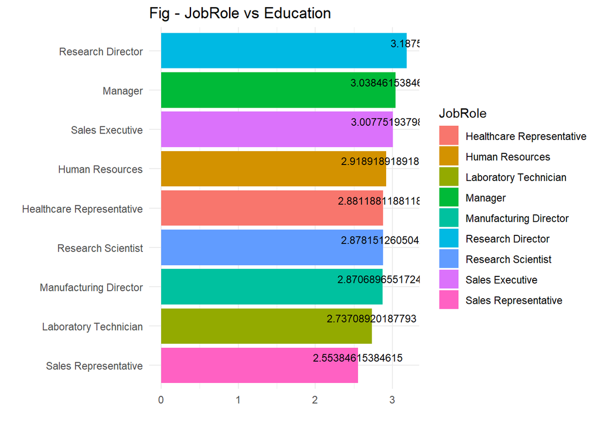

```r
names(EducationSTATOrder) <-c("JobRole", "Education")

ggplot(data=EducationSTATOrder, aes(x=reorder(JobRole,Education), y=Education, fill =JobRole)) +
geom_bar(stat="identity")+ coord_flip()+ geom_text(aes(label=Education), vjust=-0.5, size=3)+
  theme_minimal()+labs(title = "Fig - JobRole vs Education ",x="",y="")
```

```r
  #caculate the mean of DF2$JobSatisfaction for each category(DF2$JobRoleINT); aggregate by group and get mean
JobSatisfactionSTAT<-aggregate(DF2$JobSatisfaction, list(DF2$JobRole), mean)
summary(JobSatisfactionSTAT)
```

```
##                       Group.1        x
##  Healthcare Representative:1   Min.   :2.568
##  Human Resources          :1   1st Qu.:2.685
##  Laboratory Technician    :1   Median :2.738
##  Manager                  :1   Mean   :2.713
##  Manufacturing Director   :1   3rd Qu.:2.756
##  Research Director        :1   Max.   :2.803
##  (Other)                  :3
```

```r
#sort(JobSatisfactionSTAT$x, decreasing = FALSE)

JobSatisfactionSTATOrder<-JobSatisfactionSTAT[order(JobSatisfactionSTAT$x),c(1,2)]
JobSatisfactionSTATOrder
```

```
##                     Group.1        x
## 2           Human Resources 2.567568
## 6         Research Director 2.625000
## 3     Laboratory Technician 2.685446
## 4                   Manager 2.692308
## 9      Sales Representative 2.738462
## 5    Manufacturing Director 2.750000
## 8           Sales Executive 2.755814
## 1 Healthcare Representative 2.801980
## 7        Research Scientist 2.802521
```

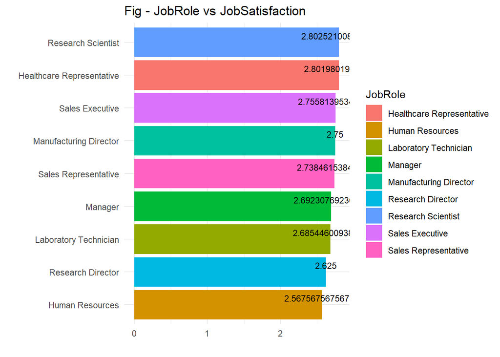

```r
names(JobSatisfactionSTATOrder) <-c("JobRole", "JobSatisfaction")

ggplot(data=JobSatisfactionSTATOrder, aes(x=reorder(JobRole,JobSatisfaction), y=JobSatisfaction, fill =JobRole)) +
geom_bar(stat="identity")+ coord_flip()+ geom_text(aes(label=JobSatisfaction), vjust=-0.5, size=3)+
  theme_minimal()+labs(title = "Fig - JobRole vs JobSatisfaction ",x="",y="")
```

```r
#caculate the mean of DF2$RelationshipSatisfaction for each category(DF2$JobRoleINT); aggregate by group and get mean
RelationshipSatisfactionSTAT<-aggregate(DF2$RelationshipSatisfaction, list(DF2$JobRole), mean)
summary(RelationshipSatisfactionSTAT)
```

```
##                       Group.1        x
##  Healthcare Representative:1   Min.   :2.508
##  Human Resources          :1   1st Qu.:2.695
##  Laboratory Technician    :1   Median :2.733
##  Manager                  :1   Mean   :2.707
##  Manufacturing Director   :1   3rd Qu.:2.756
##  Research Director        :1   Max.   :2.769
##  (Other)                  :3
```

```r
#sort(RelationshipSatisfactionSTAT$x, decreasing = FALSE)

RelationshipSatisfactionSTATOrder<-RelationshipSatisfactionSTAT[order(RelationshipSatisfactionSTAT$x),c(1,2)]
RelationshipSatisfactionSTATOrder
```

```
##                     Group.1        x
## 9      Sales Representative 2.507692
## 6         Research Director 2.687500
## 3     Laboratory Technician 2.694836
## 7        Research Scientist 2.718487
## 1 Healthcare Representative 2.732673
## 5    Manufacturing Director 2.741379
## 8           Sales Executive 2.755814
## 2           Human Resources 2.756757
## 4                   Manager 2.769231
```

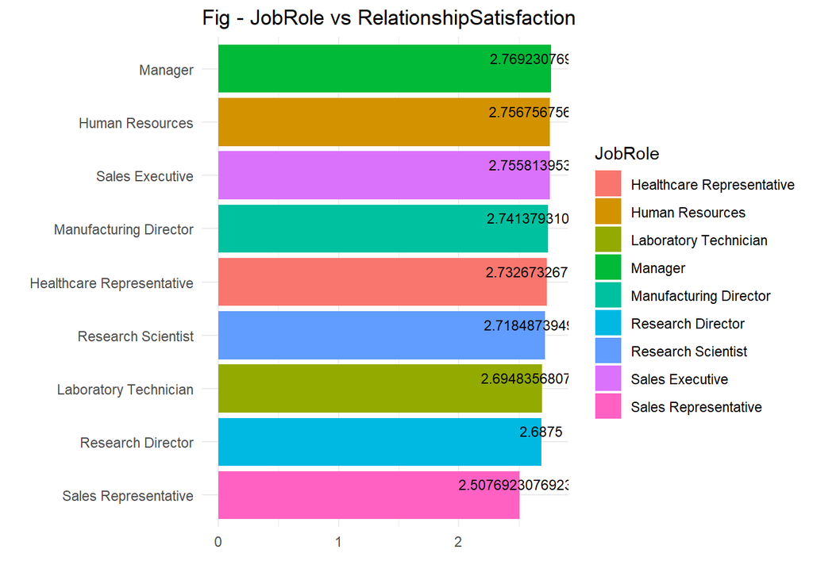

```r
names(RelationshipSatisfactionSTATOrder) <-c("JobRole", "RelationshipSatisfaction")

ggplot(data=RelationshipSatisfactionSTATOrder, aes(x=reorder(JobRole,RelationshipSatisfaction), y=RelationshipSatisfaction, fill =JobRole)) +
geom_bar(stat="identity")+ coord_flip()+ geom_text(aes(label=RelationshipSatisfaction), vjust=-0.5, size=3)+
  theme_minimal()+labs(title = "Fig - JobRole vs RelationshipSatisfaction ",x="",y="")
```

```r
#caculate the mean of DF2$WorkLifeBalance for each category(DF2$JobRoleINT); aggregate by group and get mean
WorkLifeBalanceSTAT<-aggregate(DF2$WorkLifeBalance, list(DF2$JobRole), mean)
summary(WorkLifeBalanceSTAT)
```

```
##                       Group.1        x
##  Healthcare Representative:1   Min.   :2.668
##  Human Resources          :1   1st Qu.:2.714
##  Laboratory Technician    :1   Median :2.808
##  Manager                  :1   Mean   :2.803
##  Manufacturing Director   :1   3rd Qu.:2.859
##  Research Director        :1   Max.   :3.000
##  (Other)                  :3
```

```r
#sort(WorkLifeBalanceSTAT$x, decreasing = FALSE)

WorkLifeBalanceSTATOrder<-WorkLifeBalanceSTAT[order(WorkLifeBalanceSTAT$x),c(1,2)]
WorkLifeBalanceSTATOrder
```

```
##                     Group.1        x
## 7        Research Scientist 2.668067
## 1 Healthcare Representative 2.712871
## 3     Laboratory Technician 2.713615
## 5    Manufacturing Director 2.758621
## 4                   Manager 2.807692
## 8           Sales Executive 2.810078
## 6         Research Director 2.859375
## 9      Sales Representative 2.892308
## 2           Human Resources 3.000000
```

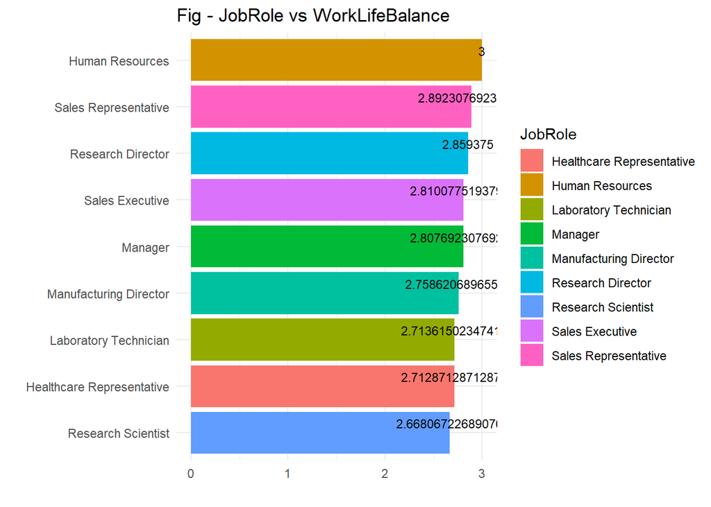

```r
names(WorkLifeBalanceSTATOrder) <-c("JobRole", "WorkLifeBalance")

ggplot(data=WorkLifeBalanceSTATOrder, aes(x=reorder(JobRole,WorkLifeBalance), y=WorkLifeBalance, fill =JobRole)) +
geom_bar(stat="identity")+ coord_flip()+ geom_text(aes(label=WorkLifeBalance), vjust=-0.5, size=3)+
  theme_minimal()+labs(title = "Fig - JobRole vs WorkLifeBalance ",x="",y="")
```

```r
#caculate the mean of DF2$JobInvolvement for each category(DF2$JobRoleINT); aggregate by group and get mean
JobInvolvementSTAT<-aggregate(DF2$JobInvolvement, list(DF2$JobRole), mean)
summary(JobInvolvementSTAT)
```

```
##                       Group.1        x
##  Healthcare Representative:1   Min.   :2.655
##  Human Resources          :1   1st Qu.:2.695
##  Laboratory Technician    :1   Median :2.757
##  Manager                  :1   Mean   :2.749
##  Manufacturing Director   :1   3rd Qu.:2.808
##  Research Director        :1   Max.   :2.836
##  (Other)                  :3
```

```r
#sort(JobInvolvementSTAT$x, decreasing = FALSE)

JobInvolvementSTATOrder<-JobInvolvementSTAT[order(JobInvolvementSTAT$x),c(1,2)]
JobInvolvementSTATOrder
```

```
##                     Group.1        x
## 5    Manufacturing Director 2.655172
## 9      Sales Representative 2.676923
## 3     Laboratory Technician 2.694836
## 8           Sales Executive 2.701550
## 2           Human Resources 2.756757
## 1 Healthcare Representative 2.782178
## 4                   Manager 2.807692
## 6         Research Director 2.828125
## 7        Research Scientist 2.836134
```

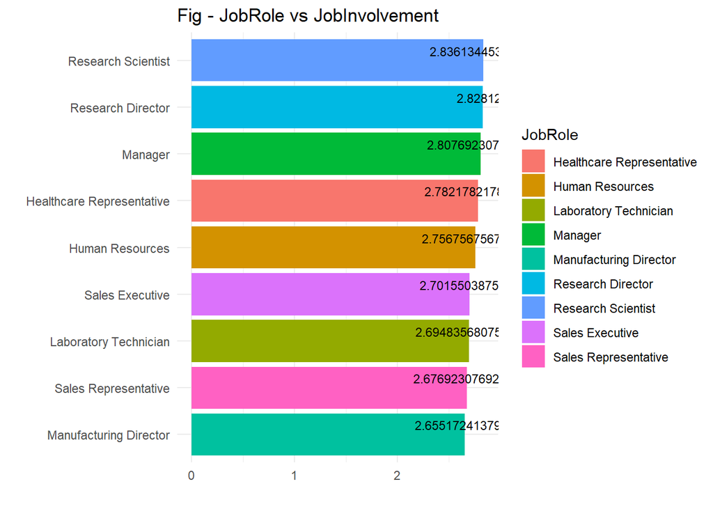

```r
names(JobInvolvementSTATOrder) <-c("JobRole", "JobInvolvement")

ggplot(data=JobInvolvementSTATOrder, aes(x=reorder(JobRole,JobInvolvement), y=JobInvolvement, fill =JobRole)) +
geom_bar(stat="identity")+ coord_flip()+ geom_text(aes(label=JobInvolvement), vjust=-0.5, size=3)+
  theme_minimal()+labs(title = "Fig - JobRole vs JobInvolvement ",x="",y="")
```

```r
#caculate the mean of DF2$PerformanceRating for each category(DF2$JobRoleINT); aggregate by group and get mean
PerformanceRatingSTAT<-aggregate(DF2$PerformanceRating, list(DF2$JobRole), mean)
summary(PerformanceRatingSTAT)
```

```
##                       Group.1        x
##  Healthcare Representative:1   Min.   :3.094
##  Human Resources          :1   1st Qu.:3.135
##  Laboratory Technician    :1   Median :3.150
##  Manager                  :1   Mean   :3.153
##  Manufacturing Director   :1   3rd Qu.:3.164
##  Research Director        :1   Max.   :3.207
##  (Other)                  :3
```

```r
#sort(PerformanceRatingSTAT$x, decreasing = FALSE)

PerformanceRatingSTATOrder<-PerformanceRatingSTAT[order(PerformanceRatingSTAT$x),c(1,2)]
PerformanceRatingSTATOrder
```

```
##                     Group.1        x
## 6         Research Director 3.093750
## 8           Sales Executive 3.127907
## 2           Human Resources 3.135135
## 1 Healthcare Representative 3.138614
## 3     Laboratory Technician 3.150235
## 9      Sales Representative 3.153846
## 7        Research Scientist 3.163866
## 4                   Manager 3.205128
## 5    Manufacturing Director 3.206897
```

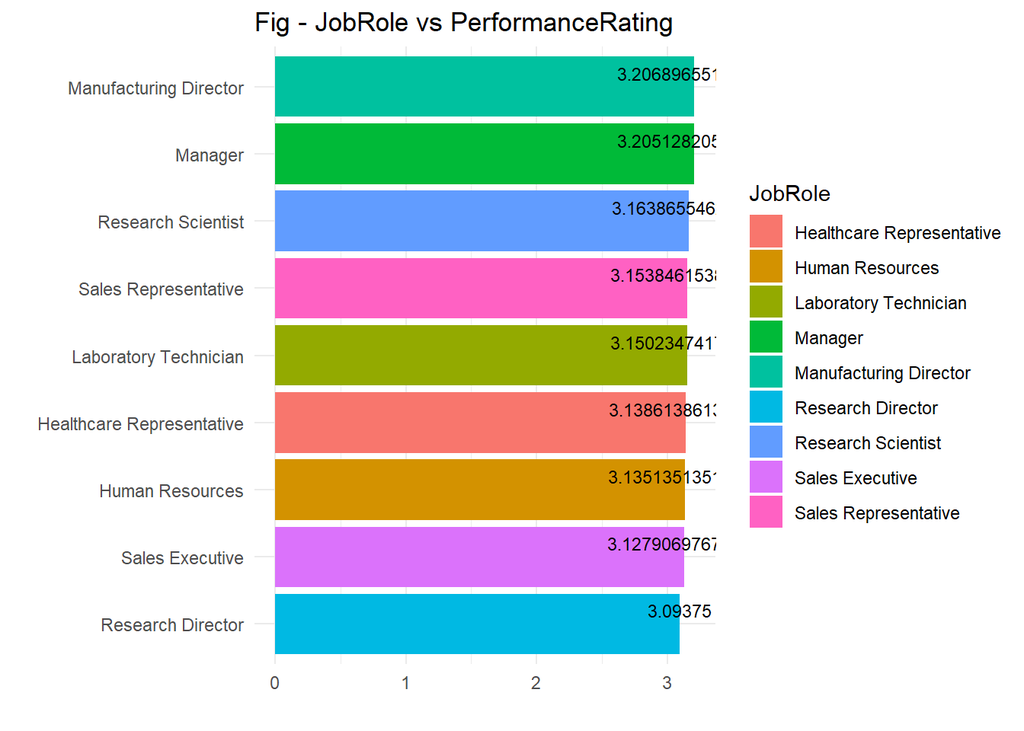

```r
names(PerformanceRatingSTATOrder) <-c("JobRole", "PerformanceRating")

ggplot(data=PerformanceRatingSTATOrder, aes(x=reorder(JobRole,PerformanceRating), y=PerformanceRating, fill =JobRole)) +
geom_bar(stat="identity")+ coord_flip()+ geom_text(aes(label=PerformanceRating), vjust=-0.5, size=3)+
  theme_minimal()+labs(title = "Fig - JobRole vs PerformanceRating ",x="",y="")
```

```r
#caculate the mean of DF2$EnvironmentSatisfaction for each category(DF2$JobRoleINT); aggregate by group and get mean
EnvironmentSatisfactionSTAT<-aggregate(DF2$EnvironmentSatisfaction, list(DF2$JobRole), mean)
summary(EnvironmentSatisfactionSTAT)
```

```
##                       Group.1        x
##  Healthcare Representative:1   Min.   :2.391
##  Human Resources          :1   1st Qu.:2.664
##  Laboratory Technician    :1   Median :2.682
##  Manager                  :1   Mean   :2.697
##  Manufacturing Director   :1   3rd Qu.:2.775
##  Research Director        :1   Max.   :2.897
##  (Other)                  :3
```

```r
#sort(EnvironmentSatisfactionSTAT$x, decreasing = FALSE)

EnvironmentSatisfactionSTATOrder<-EnvironmentSatisfactionSTAT[order(EnvironmentSatisfactionSTAT$x),c(1,2)]
EnvironmentSatisfactionSTATOrder
```

```
##                     Group.1        x
## 6         Research Director 2.390625
## 9      Sales Representative 2.646154
## 7        Research Scientist 2.663866
## 2           Human Resources 2.675676
## 8           Sales Executive 2.682171
## 1 Healthcare Representative 2.752475
## 3     Laboratory Technician 2.774648
## 4                   Manager 2.794872
## 5    Manufacturing Director 2.896552
```

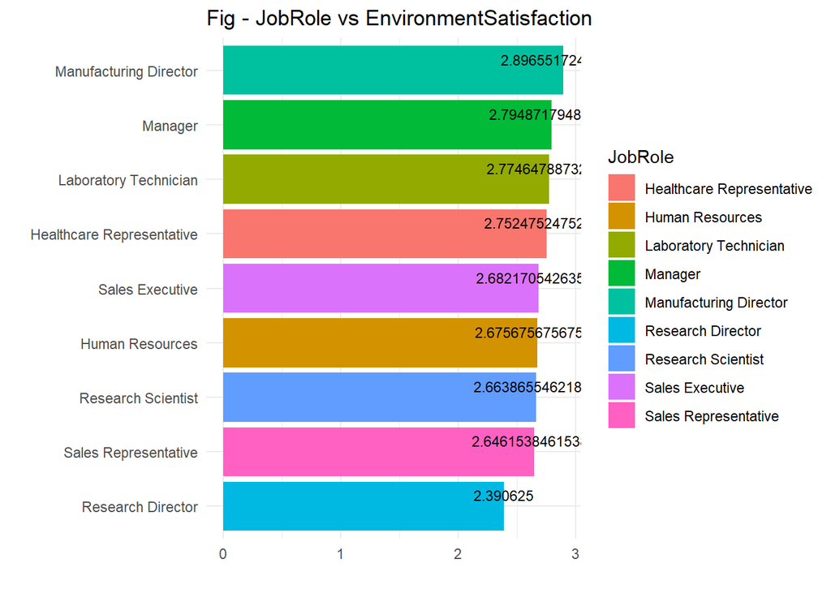

```r
names(EnvironmentSatisfactionSTATOrder) <-c("JobRole", "EnvironmentSatisfaction")

ggplot(data=EnvironmentSatisfactionSTATOrder, aes(x=reorder(JobRole,EnvironmentSatisfaction), y=EnvironmentSatisfaction, fill =JobRole)) +
geom_bar(stat="identity")+ coord_flip()+ geom_text(aes(label=EnvironmentSatisfaction), vjust=-0.5, size=3)+
  theme_minimal()+labs(title = "Fig - JobRole vs EnvironmentSatisfaction ",x="",y="")
```

## Objective 3. Build a model to predict attrition.

#### Four different models were built and compared, they are Naive Bayes, Random Forest, Custom logistic regression (built with the top 15 important features selected in previous steps) and XGBoost. XGBoost were perfromed in Python, so find the analysis in attached file gxboostCS2,ipynb.

### Fitting the Naive Bayes Model

```r
#Fitting the Naive Bayes modelï¼ Accuracyï¼ 81.33%
dfTrain <-read.csv("C:/Users/N1110/Desktop/CaseStudy2-data.csv",header=TRUE)
dfVal <- read.csv("C:/Users/N1110/Desktop/CaseStudy2Validation.csv",header=TRUE)

#fits the model on only the training set
library(e1071)
Naive_Bayes_Model=naiveBayes( Attrition~., data=dfTrain)
#What does the model say? Print the model summary
#Naive_Bayes_Model

#uses that model to predict the labels of the test set
#Prediction on the dataset
dfPreds0=predict(Naive_Bayes_Model,dfVal)

#Confusion matrix to check accuracy
#ctable(NB_Predictions,dfVal0$Attrition)
library(caret)
confusionMatrix(table(dfPreds0,dfVal$Attrition))
```

```
## Confusion Matrix and Statistics
##
##
## dfPreds0  No Yes
##      No  214  19
##      Yes  37  30
##
##                Accuracy : 0.8133
##                  95% CI : (0.7646, 0.8558)
##     No Information Rate : 0.8367
##     P-Value [Acc > NIR] : 0.8781
##
##                   Kappa : 0.405
##  Mcnemar's Test P-Value : 0.0231
##
##             Sensitivity : 0.8526
##             Specificity : 0.6122
##          Pos Pred Value : 0.9185
##          Neg Pred Value : 0.4478
##              Prevalence : 0.8367
##          Detection Rate : 0.7133
##    Detection Prevalence : 0.7767
##       Balanced Accuracy : 0.7324
##
##        'Positive' Class : No
##
```

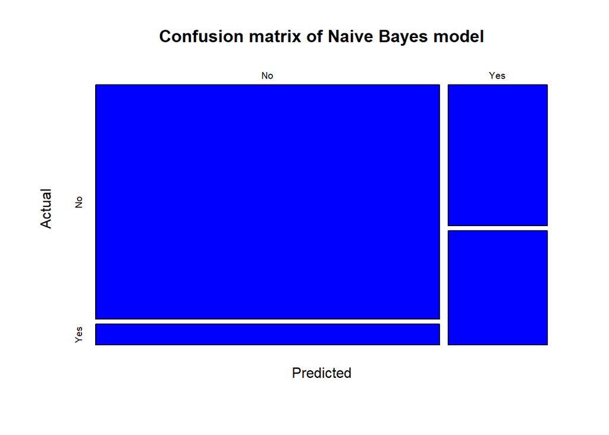

```r
cMatrix<-table(dfPreds0, dfVal$Attrition)

#par(mfrow=c(1 ,2))
plot(cMatrix, col="blue", ylab="Actual", xlab="Predicted",main="Confusion matrix of Naive Bayes model")
```

#### Outputting the Naive Bayes Model

```r
#Outputting
dfPreds1=cbind(dfVal$ID, dfPreds0)
#make a dataframe with only the ids in one column and the labels in the second column
dfPreds=as.data.frame(dfPreds1)

names(dfPreds)<- c("ID", "Attrition")

#Outputting data-prints those ids and predictions to a csv file
write.csv(dfPreds,"C:/Users/N1110/Desktop/Case2PredictionsJiang.csv",row.names = FALSE)

# Our output file have 2, 1 instead of Yes and No. Is it ok?
```

#### Fitting models Random Forest and Custom logistic regression (built with the top 15 important features selected in previous steps)

```r
#Random Forest modelï¼Accuracyï¼ model1=85%

dfTrain0 <-read.csv("C:/Users/N1110/Desktop/CaseStudy2-data.csv",header=TRUE)
dfVal0 <- read.csv("C:/Users/N1110/Desktop/CaseStudy2Validation.csv",header=TRUE)

library(randomForest)
# Create a Random Forest model with default parameters
model1 <- randomForest(Attrition~., data=dfTrain0, importance = TRUE)
model1
```

```
##
## Call:
##  randomForest(formula = Attrition ~ ., data = dfTrain0, importance = TRUE)
##                Type of random forest: classification
##                      Number of trees: 500
## No. of variables tried at each split: 6
##
##         OOB estimate of  error rate: 14.19%
## Confusion matrix:
##      No Yes class.error
## No  975   7  0.00712831
## Yes 159  29  0.84574468
```

```r
# Predicting on train set
predTrain <- predict(model1, dfVal0, type = "class")
# Checking classification accuracy
library(caret)
confusionMatrix(table(predTrain, dfVal0$Attrition))
```

```
## Confusion Matrix and Statistics
##
##
## predTrain  No Yes
##       No  250  42
##       Yes   1   7
##
##                Accuracy : 0.8567
##                  95% CI : (0.8118, 0.8943)
##     No Information Rate : 0.8367
##     P-Value [Acc > NIR] : 0.1964
##
##                   Kappa : 0.2094
##  Mcnemar's Test P-Value : 1.061e-09
##
##             Sensitivity : 0.9960
##             Specificity : 0.1429
##          Pos Pred Value : 0.8562
##          Neg Pred Value : 0.8750
##              Prevalence : 0.8367
##          Detection Rate : 0.8333
##    Detection Prevalence : 0.9733
##       Balanced Accuracy : 0.5694
##
##        'Positive' Class : No
##
```

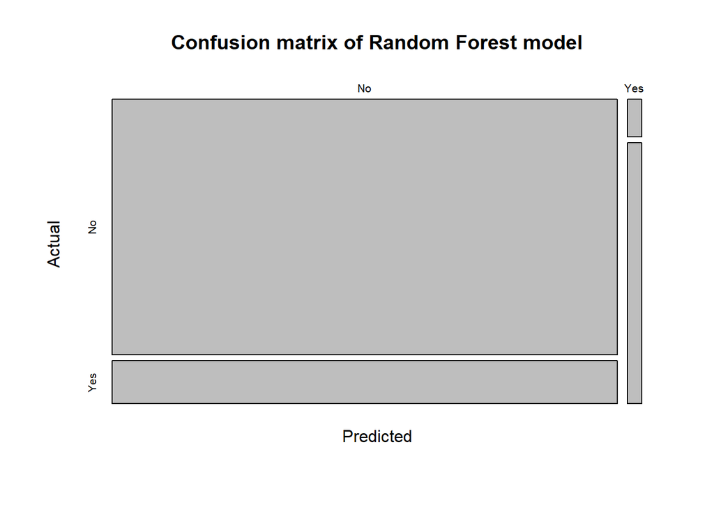

```r
cMatrix<-table(predTrain, dfVal0$Attrition)
plot(cMatrix,ylab="Actual", xlab="Predicted",main="Confusion matrix of Random Forest model")
```

```r
# To check important variables
importance(model1)
```

```
##                                  No        Yes MeanDecreaseAccuracy
## ID                        1.2017639 -0.6935591          0.712283999
## Age                       6.5709159  7.6953688          9.458531843
## BusinessTravel            2.9973531  3.0203119          3.990627155
## DailyRate                -0.1604308 -0.3048586         -0.249570409
## Department                2.0709408  0.4167611          2.120256751
## DistanceFromHome         -0.5977775  1.0284179         -0.004302907
## Education                 2.1602239 -1.2992331          1.376688676
## EducationField            0.5812031  0.2149925          0.499310498
## EmployeeCount             0.0000000  0.0000000          0.000000000
## EmployeeNumber           -0.2992445 -1.6048815         -0.916262215
## EnvironmentSatisfaction   1.5282315  5.4273021          4.057564303
## Gender                    0.6347532  0.3734907          0.717943013
## HourlyRate                1.0351726  0.1364364          1.029050594
## JobInvolvement            4.5078199  4.7238348          6.182077530
## JobLevel                  4.8416651  6.9432725          7.700170242
## JobRole                   8.0549870  6.0256073          9.860269927
## JobSatisfaction           0.9076358  3.4996854          2.272976222
## MaritalStatus             5.9157729  4.4711673          7.585270314
## MonthlyIncome             6.0581851  4.0556690          8.102596277
## MonthlyRate              -1.4687392 -0.6271208         -1.607488049
## NumCompaniesWorked        3.6089212  3.3634159          4.901769858
## Over18                    0.0000000  0.0000000          0.000000000
## OverTime                 10.7731953 17.3027236         17.349150020
## PercentSalaryHike         2.1458720 -1.2808668          1.308483072
## PerformanceRating        -1.0448451  0.9703463         -0.395782746
## RelationshipSatisfaction  1.0060577  1.8226434          1.699515948
## StandardHours             0.0000000  0.0000000          0.000000000
## StockOptionLevel          7.2677422  9.9462097         10.697683225
## TotalWorkingYears         8.9296348  5.2333730         10.888724747
## TrainingTimesLastYear    -0.1804745 -0.2510217         -0.283773966
## WorkLifeBalance           2.8046471  5.8972572          4.907216997
## YearsAtCompany            5.2616897  4.5203076          6.775012632
## YearsInCurrentRole        2.4216216  3.9269843          4.413334373
## YearsSinceLastPromotion   3.7813579  1.0029552          3.899281967
## YearsWithCurrManager      3.8656316  4.3753655          5.879314523
## Rand                     -1.3972565  1.4813716         -0.643752525
##                          MeanDecreaseGini
## ID                              13.991914
## Age                             16.978627
```

[output cut: 19 more lines]

```
## Over18                           0.000000
## OverTime                        14.908012
## PercentSalaryHike                9.294831
## PerformanceRating                1.287026
## RelationshipSatisfaction         6.264264
## StandardHours                    0.000000
## StockOptionLevel                 9.161199
## TotalWorkingYears               13.400098
## TrainingTimesLastYear            6.447856
## WorkLifeBalance                  7.921018
## YearsAtCompany                  12.629056
## YearsInCurrentRole               6.685052
## YearsSinceLastPromotion          7.793682
## YearsWithCurrManager             8.089505
## Rand                            13.562675
```

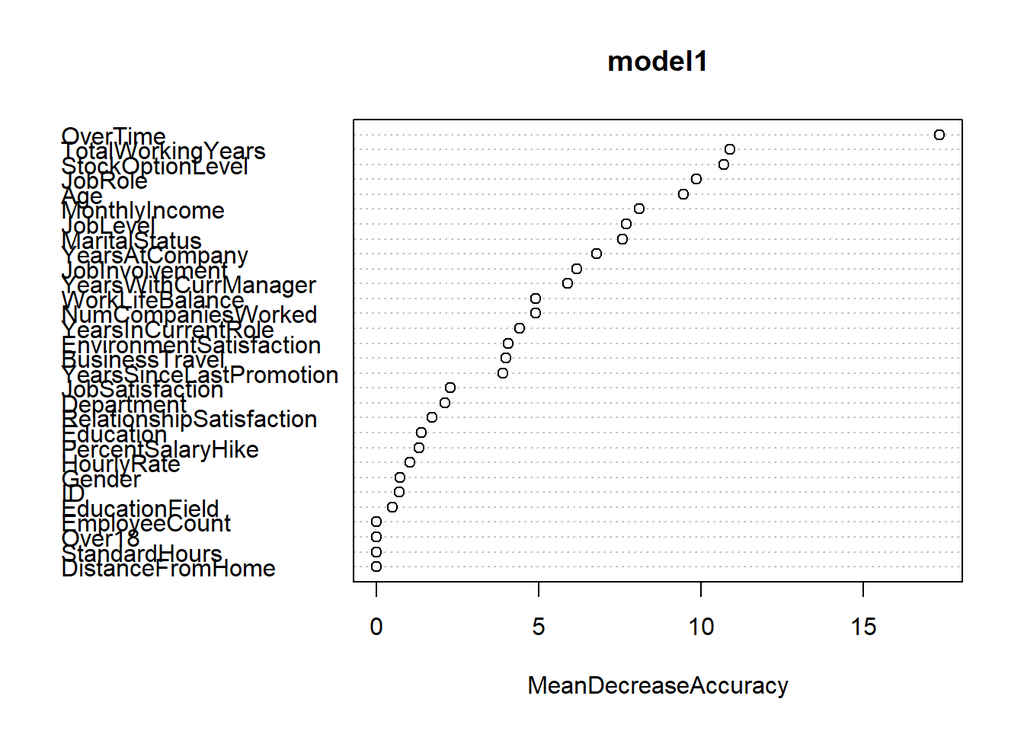

```r
#varImpPlot(model1)
varImpPlot(model1,type=1)
```

```r
 # Feature importance plot using Random Forest. type 1 the mean decrease in accuracy,type2 mean decrease in node impurity.
#we use type 1 here, The more the accuracy of the random forest decreases due to the exclusion (or permutation) of a single variable,
#the more important that variable is deemed, and therefore variables with a large mean decrease in accuracy are more important for classification of the data.
#The mean decrease in Gini coefficient is a measure of how each variable contributes to the homogeneity of the nodes and leaves in the resulting random forest. ...
# Variables that result in nodes with higher purity have a higher decrease in Gini coefficient.
#RF is one of the predictive modeling algorithms perform feature importance and selection internally while constructing their mode
dfTrain <-read.csv("C:/Users/N1110/Desktop/CaseStudy2-data.csv",header=TRUE)
dfVal <- read.csv("C:/Users/N1110/Desktop/CaseStudy2Validation.csv",header=TRUE)

dfTrain.train <- dfTrain

dfTrain.test <- dfVal


#Custom Logistic Regression (built with the top 15 important features selected in previous steps)
#modelCUSTOM1 <- glm(Attrition~., data = dfTrain.train, family=binomial)

modelCUSTOM <- glm(Attrition~OverTime +MaritalStatus +JobInvolvement +  YearsInCurrentRole+  MonthlyIncome+StockOptionLevel+Age  +  EnvironmentSatisfaction  + WorkLifeBalance + JobSatisfaction  + Department  + DistanceFromHome  +  JobRole  + TrainingTimesLastYear +  NumCompaniesWorked, data = dfTrain.train, family=binomial)


predictfun <- function(fit, test)

{
p <- ifelse(predict(fit, test, type="response") > 0.5, "Yes", "No")
 p
}
#Tests the models


predCUSTOM <- as.vector(predictfun(modelCUSTOM, dfTrain.test))


#Creates the confusion matrix with all those stats
library(caret)
COSTUMcMatrix <- confusionMatrix(table(dfTrain.test$Attrition, predCUSTOM))
COSTUMcMatrix
```

```
## Confusion Matrix and Statistics
##
##      predCUSTOM
##        No Yes
##   No  247   4
##   Yes  37  12
##
##                Accuracy : 0.8633
##                  95% CI : (0.8192, 0.9001)
##     No Information Rate : 0.9467
##     P-Value [Acc > NIR] : 1
##
##                   Kappa : 0.3141
##  Mcnemar's Test P-Value : 5.806e-07
##
##             Sensitivity : 0.8697
##             Specificity : 0.7500
##          Pos Pred Value : 0.9841
##          Neg Pred Value : 0.2449
##              Prevalence : 0.9467
##          Detection Rate : 0.8233
##    Detection Prevalence : 0.8367
##       Balanced Accuracy : 0.8099
##
##        'Positive' Class : No
##
```

[figure not shown]

```r
plot(table(dfTrain.test$Attrition, predCUSTOM),col="green", ylab="Actual", xlab="Predicted",main="Confusion matrix of Custom model")
```